# VIDEO GAME EXPLORATORY DATA ANALYSIS AND VISUALIZATION

[figure not shown]

## Game Analysis

### I have created a game analysis to answer basic business questions. The analysis includes the following:

1. Data collection: I collected data from a kaggle free datasets.
2. Data cleaning: I preapred data to analysis.
3. Data analysis: I used EDA analysis to identify trends and patterns in the data.
4. Data visualization: I created visualizations to communicate the results of the analysis.

### The analysis was used to answer the following questions:

1. What are the most popular genres of video games?
2. Which publishers release the most games?
3. What are the most popular platforms for video games?
4. What are the most popular regions for video games?

```python
import pandas as pd
import numpy as np
import plotly.express as px
import plotly.graph_objects as go
import plotly.figure_factory as ff
import matplotlib.pyplot as plt
import seaborn as sns
```

```python
df = pd.read_csv("vgsales.csv")
region_df = pd.read_csv("video-games-developers.csv")
```

```python
df = pd.merge(df, region_df[['Developer', 'Country']],left_on='Publisher', right_on='Developer', how='left')
df.head()
```

|  | Rank | Name | Platform | Year | Genre | Publisher | NA_Sales | EU_Sales | JP_Sales | Other_Sales | Global_Sales | Developer | Country |
| --- | --- | --- | --- | --- | --- | --- | --- | --- | --- | --- | --- | --- | --- |
| 0 | 1 | Wii Sports | Wii | 2006.0 | Sports | Nintendo | 41.49 | 29.02 | 3.77 | 8.46 | 82.74 | Nintendo | Japan |
| 1 | 2 | Super Mario Bros. | NES | 1985.0 | Platform | Nintendo | 29.08 | 3.58 | 6.81 | 0.77 | 40.24 | Nintendo | Japan |
| 2 | 3 | Mario Kart Wii | Wii | 2008.0 | Racing | Nintendo | 15.85 | 12.88 | 3.79 | 3.31 | 35.82 | Nintendo | Japan |
| 3 | 4 | Wii Sports Resort | Wii | 2009.0 | Sports | Nintendo | 15.75 | 11.01 | 3.28 | 2.96 | 33.00 | Nintendo | Japan |
| 4 | 5 | Pokemon Red/Pokemon Blue | GB | 1996.0 | Role-Playing | Nintendo | 11.27 | 8.89 | 10.22 | 1.00 | 31.37 | Nintendo | Japan |

```python
df.columns
```

```
Index(['Rank', 'Name', 'Platform', 'Year', 'Genre', 'Publisher', 'NA_Sales',
       'EU_Sales', 'JP_Sales', 'Other_Sales', 'Global_Sales', 'Developer',
       'Country'],
      dtype='object')
```

```python
df.describe()
```

|  | Rank | Year | NA_Sales | EU_Sales | JP_Sales | Other_Sales | Global_Sales |
| --- | --- | --- | --- | --- | --- | --- | --- |
| count | 16598.000000 | 16327.000000 | 16598.000000 | 16598.000000 | 16598.000000 | 16598.000000 | 16598.000000 |
| mean | 8300.605254 | 2006.406443 | 0.264667 | 0.146652 | 0.077782 | 0.048063 | 0.537441 |
| std | 4791.853933 | 5.828981 | 0.816683 | 0.505351 | 0.309291 | 0.188588 | 1.555028 |
| min | 1.000000 | 1980.000000 | 0.000000 | 0.000000 | 0.000000 | 0.000000 | 0.010000 |
| 25% | 4151.250000 | 2003.000000 | 0.000000 | 0.000000 | 0.000000 | 0.000000 | 0.060000 |
| 50% | 8300.500000 | 2007.000000 | 0.080000 | 0.020000 | 0.000000 | 0.010000 | 0.170000 |
| 75% | 12449.750000 | 2010.000000 | 0.240000 | 0.110000 | 0.040000 | 0.040000 | 0.470000 |
| max | 16600.000000 | 2020.000000 | 41.490000 | 29.020000 | 10.220000 | 10.570000 | 82.740000 |

```python
print(f"{df.info()}\n")
print(f"There are {len(df.columns)} columns in the dataset.\n")
print(f"There are {len(df)} rows in the dataset.")
```

```
<class 'pandas.core.frame.DataFrame'>
Int64Index: 16598 entries, 0 to 16597
Data columns (total 13 columns):
 #   Column        Non-Null Count  Dtype
---  ------        --------------  -----
 0   Rank          16598 non-null  int64
 1   Name          16598 non-null  object
 2   Platform      16598 non-null  object
 3   Year          16327 non-null  float64
 4   Genre         16598 non-null  object
 5   Publisher     16540 non-null  object
 6   NA_Sales      16598 non-null  float64
 7   EU_Sales      16598 non-null  float64
 8   JP_Sales      16598 non-null  float64
 9   Other_Sales   16598 non-null  float64
 10  Global_Sales  16598 non-null  float64
 11  Developer     9195 non-null   object
 12  Country       9195 non-null   object
dtypes: float64(6), int64(1), object(6)
memory usage: 1.8+ MB
None

There are 13 columns in the dataset.

There are 16598 rows in the dataset.
```

# Data Cleaning

```python
df.isnull().sum()
```

```
Rank               0
Name               0
Platform           0
Year             271
Genre              0
Publisher         58
NA_Sales           0
EU_Sales           0
JP_Sales           0
Other_Sales        0
Global_Sales       0
Developer       7403
Country         7403
dtype: int64
```

```python
df = df.drop_duplicates()
```

```python
# Impute the missing values in the Developer and Country columns with the mode value
df['Developer'].fillna(df['Developer'].mode()[0], inplace=True)
df['Country'].fillna(df['Country'].mode()[0], inplace=True)
df['Year'].fillna(df['Year'].mode()[0], inplace=True)
df['Publisher'].fillna(df['Publisher'].mode()[0], inplace=True)
df.isnull().sum()
```

```
Rank            0
Name            0
Platform        0
Year            0
Genre           0
Publisher       0
NA_Sales        0
EU_Sales        0
JP_Sales        0
Other_Sales     0
Global_Sales    0
Developer       0
Country         0
dtype: int64
```

```python
# Identify and remove outliers
df = df[df['Global_Sales'] < df['Global_Sales'].quantile(0.99)]
```

```python
# Validate the data
# Check for negative sales values
assert df['Global_Sales'].min() >= 0
```

```python
# Check for invalid dates
assert df['Year'].min() >= 1900
```

# Exploratory Data Analysis

## 1. What genre games are the most popular?

```python
df_genre = df['Genre'].value_counts()
print(df_genre)
```

```
Action          3288
Sports          2335
Misc            1727
Role-Playing    1464
Adventure       1284
Shooter         1278
Racing          1233
Platform         862
Simulation       862
Fighting         841
Strategy         680
Puzzle           578
Name: Genre, dtype: int64
```

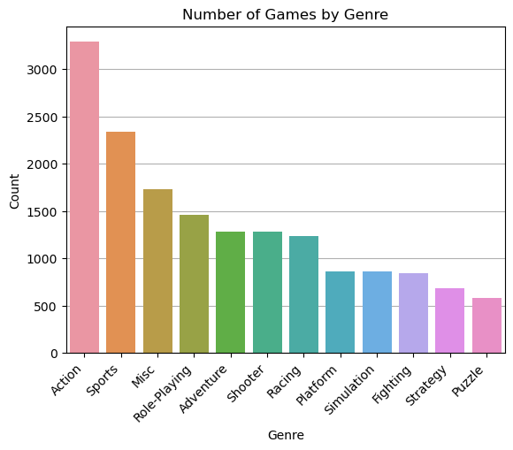

```python
sns.barplot(x=df_genre.index, y=df_genre.values, )

plt.xlabel("Genre")
plt.ylabel("Count")
plt.title("Number of Games by Genre")
plt.xticks(rotation=45, ha='right')

ax = plt.gca()
ax.set_axisbelow(True)
plt.figure(figsize=(12,8))
# Add the grid
ax.grid(axis='y')
plt.subplots_adjust(bottom=0.3)
plt.show()
```

## 2. Popularity of platforms

```python
df_platform = df['Platform'].value_counts()
top10_platforms = df_platform[:10]
print(top10_platforms)
```

```
PS2     2149
DS      2147
PS3     1306
Wii     1304
X360    1241
PSP     1211
PS      1184
PC       958
XB       822
GBA      816
Name: Platform, dtype: int64
```

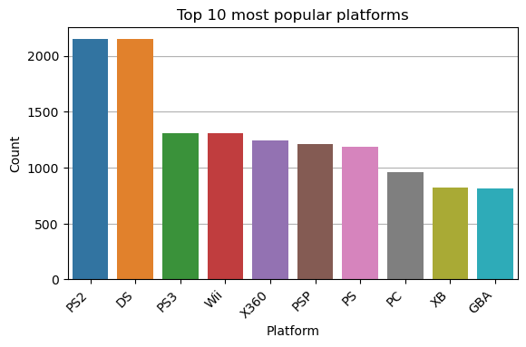

```python
sns.barplot(x=top10_platforms.index, y=top10_platforms.values, )


plt.xlabel("Platform")
plt.ylabel("Count")
plt.title("Top 10 most popular platforms")
plt.xticks(rotation=45, ha='right')

ax = plt.gca()
ax.set_axisbelow(True)
# Add the grid
ax.grid(axis='y')
plt.subplots_adjust(bottom=0.3)
plt.show()
```

## 3. In what year were the most games released?

```python
top_years = df.groupby(by=['Year'])['Name'].count().sort_values(ascending=False)
```

### Most games were released in the following years:

#### YEAR : NUMBER OF GAMES

#### 2009 : 1689

#### 2008 : 1418

#### 2010 : 1245

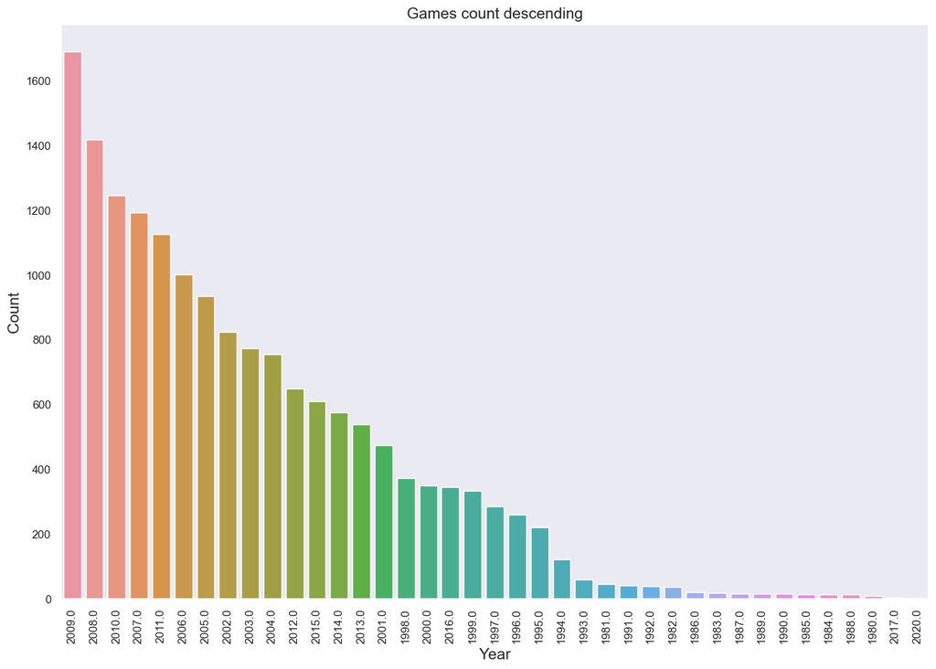

```python
plt.figure(figsize=(15, 10))
sns.countplot(x="Year", data=df, order = top_years.index)
plt.grid(axis='y')
plt.xticks(rotation=90)
plt.xlabel("Year",fontsize = 15)
plt.ylabel("Count",fontsize = 15)
plt.title("Games count descending",fontsize = 15)
```

## 4. Which year had the highest sales worldwide?

```python
data_year = df.groupby(by=['Year'])['Global_Sales'].sum()
data_year = data_year.reset_index()
```

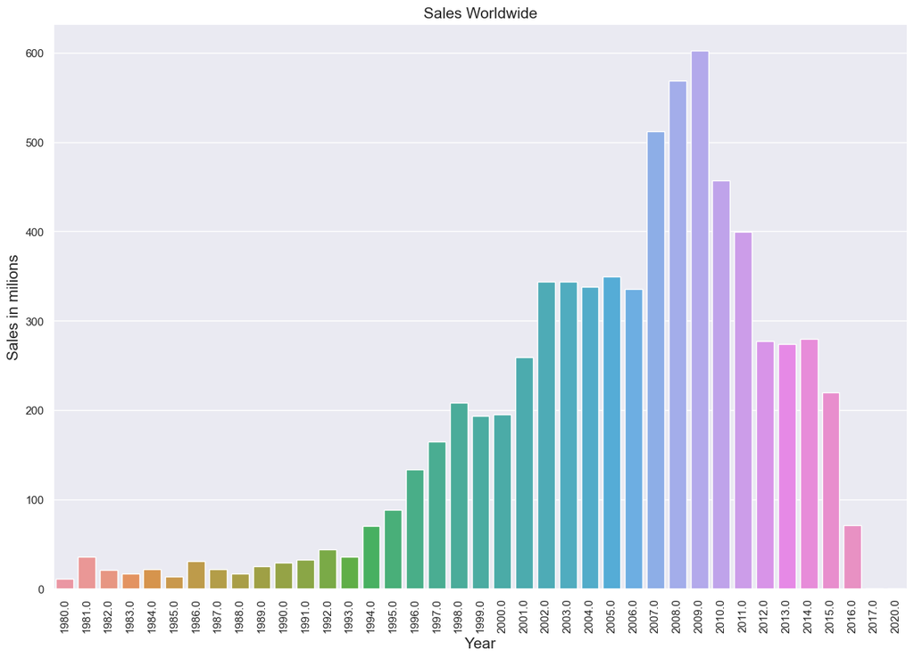

```python
plt.figure(figsize=(15, 10))
sns.barplot(x="Year", y="Global_Sales", data=data_year)
plt.xticks(rotation=90)
plt.xlabel("Year",fontsize = 15)
plt.ylabel("Sales in milions", fontsize = 15)
plt.title("Sales Worldwide",fontsize = 15)
```

### The largest number of games were sold in 2007-2011

## 5. Comparison of sales depending on the genre of the film

```python
comp_genre = df[['Genre', 'NA_Sales', 'EU_Sales', 'JP_Sales', 'Other_Sales']]
comp_map = comp_genre.groupby(by=['Genre']).sum()
```

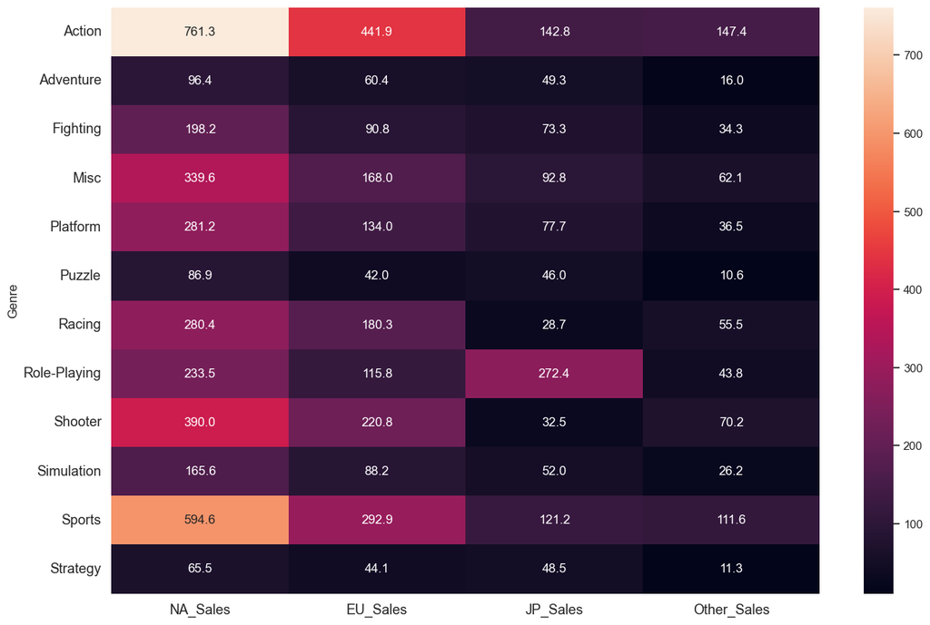

```python
plt.figure(figsize=(15, 10))
sns.set(font_scale=1)
sns.heatmap(comp_map, annot=True, fmt = '.1f')

plt.xticks(fontsize=13)
plt.yticks(fontsize=13)
plt.show()
```

```python
comp_table = comp_map.reset_index()
comp_table = pd.melt(comp_table, id_vars=['Genre'], value_vars=['NA_Sales', 'EU_Sales', 'JP_Sales', 'Other_Sales'], var_name='Sale_Area', value_name='Sale_Price')
comp_table.head()
```

|  | Genre | Sale_Area | Sale_Price |
| --- | --- | --- | --- |
| 0 | Action | NA_Sales | 761.28 |
| 1 | Adventure | NA_Sales | 96.36 |
| 2 | Fighting | NA_Sales | 198.24 |
| 3 | Misc | NA_Sales | 339.64 |
| 4 | Platform | NA_Sales | 281.18 |

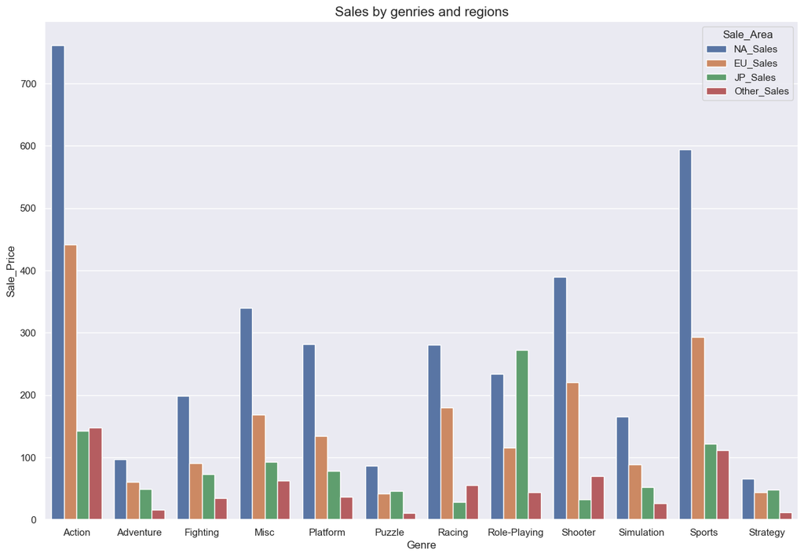

```python
plt.figure(figsize=(15, 10))
sns.barplot(x='Genre', y='Sale_Price', hue='Sale_Area', data=comp_table)
plt.title("Sales by genries and regions",fontsize = 15)
```